# Analyzing Individual BGG Users

Phil Henrickson

2021-11-27

Load previously queried training and test data from the local layer.

Set function for displaying probabilities

Fit models and analyze collection for **Watch%20It%20Played**.

## Games in Collection

How many games has the user owned/played in the training set (games prior to 2020)?

```
## # A tibble: 1 × 3
##   username            games_owned games_played
##   <chr>                     <dbl>        <dbl>
## 1 Watch%20It%20Played         229            0
```

## Coefficients for Watch%20It%20Played

Examine coefficients from the trained model.

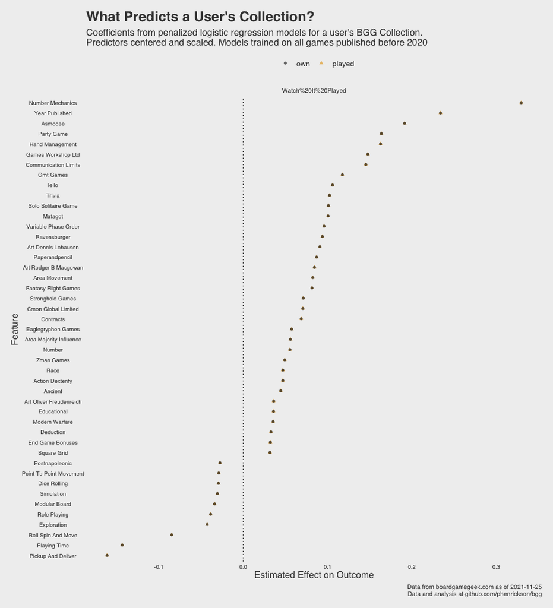

## Separation Plot and Assessment

Examine separation plot for training set (cross validated predictions).

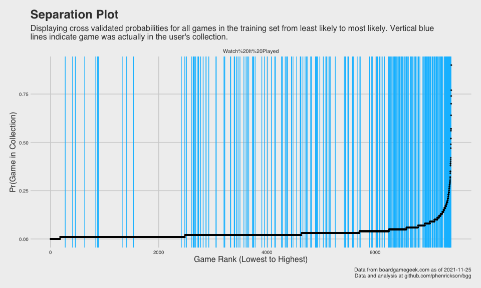

Formally assess how well the model did in resampling.

| outcome_type | .metric | .estimator | .estimate |
| --- | --- | --- | --- |
| own | roc_auc | binary | 0.77 |
| played | roc_auc | binary | 0.77 |

## Predicted Games in Collection from Training

Examine top games from resampling.

Top Overall Games for User from Resampling

| username | yearpublished | game_id | name | pred_played | pred_own | actual_played | actual_own |
| --- | --- | --- | --- | --- | --- | --- | --- |
| Watch%20It%20Played | 2018 | 205896 | Rising Sun | 0.90 | 0.90 | 0 | 0 |
| Watch%20It%20Played | 2017 | 174430 | Gloomhaven | 0.77 | 0.77 | 0 | 0 |
| Watch%20It%20Played | 2018 | 244711 | Newton | 0.74 | 0.74 | 0 | 0 |
| Watch%20It%20Played | 2019 | 283863 | The Magnificent | 0.70 | 0.70 | 0 | 0 |
| Watch%20It%20Played | 2018 | 199792 | Everdell | 0.64 | 0.64 | 0 | 0 |
| Watch%20It%20Played | 2016 | 177590 | 13 Days: The Cuban Missile Crisis | 0.57 | 0.57 | 0 | 0 |
| Watch%20It%20Played | 2014 | 156129 | Deception: Murder in Hong Kong | 0.57 | 0.57 | 0 | 0 |
| Watch%20It%20Played | 2016 | 198773 | Codenames: Pictures | 0.56 | 0.56 | 0 | 0 |
| Watch%20It%20Played | 2015 | 181304 | Mysterium | 0.52 | 0.52 | 1 | 1 |
| Watch%20It%20Played | 2016 | 198454 | When I Dream | 0.49 | 0.49 | 0 | 0 |
| Watch%20It%20Played | 2016 | 155821 | Inis | 0.47 | 0.47 | 1 | 1 |
| Watch%20It%20Played | 2015 | 178900 | Codenames | 0.42 | 0.42 | 1 | 1 |
| Watch%20It%20Played | 2019 | 270971 | Era: Medieval Age | 0.41 | 0.41 | 0 | 0 |
| Watch%20It%20Played | 2016 | 205158 | Codenames: Deep Undercover | 0.40 | 0.40 | 0 | 0 |
| Watch%20It%20Played | 1997 | 42 | Tigris & Euphrates | 0.39 | 0.39 | 0 | 0 |
| Watch%20It%20Played | 2018 | 231327 | The Grizzled: Armistice Edition | 0.39 | 0.39 | 0 | 0 |
| Watch%20It%20Played | 2019 | 276025 | Maracaibo | 0.38 | 0.38 | 0 | 0 |
| Watch%20It%20Played | 2010 | 62227 | Labyrinth: The War on Terror, 2001 – ? | 0.35 | 0.35 | 0 | 0 |
| Watch%20It%20Played | 2009 | 54998 | Cyclades | 0.35 | 0.35 | 1 | 1 |
| Watch%20It%20Played | 2016 | 205322 | The Oregon Trail Card Game | 0.34 | 0.34 | 0 | 0 |
| Watch%20It%20Played | 2004 | 9220 | Saboteur | 0.32 | 0.32 | 0 | 0 |
| Watch%20It%20Played | 2008 | 38453 | Space Alert | 0.32 | 0.32 | 0 | 0 |
| Watch%20It%20Played | 2010 | 62219 | Dominant Species | 0.31 | 0.31 | 0 | 0 |
| Watch%20It%20Played | 2014 | 144189 | Fire in the Lake | 0.30 | 0.30 | 1 | 1 |
| Watch%20It%20Played | 2016 | 163154 | Falling Sky: The Gallic Revolt Against Caesar | 0.30 | 0.30 | 1 | 1 |
| Watch%20It%20Played | 2013 | 144239 | Impulse | 0.30 | 0.30 | 0 | 0 |
| Watch%20It%20Played | 2017 | 224037 | Codenames: Duet | 0.29 | 0.29 | 1 | 1 |
| Watch%20It%20Played | 2017 | 180199 | Colonial Twilight: The French-Algerian War, 1954-62 | 0.29 | 0.29 | 1 | 1 |
| Watch%20It%20Played | 2019 | 251247 | Barrage | 0.29 | 0.29 | 0 | 0 |
| Watch%20It%20Played | 2019 | 284108 | Pictures | 0.29 | 0.29 | 0 | 0 |

[output cut: 70 more lines]

#### Most and Least Likely Games

What game does the model think Watch%20It%20Played is **most likely to own** that is **not** in their collection?

| username | yearpublished | game_id | name | pred_own |
| --- | --- | --- | --- | --- |
| Watch%20It%20Played | 2018 | 205896 | Rising Sun | 0.9 |

What game does the model think Watch%20It%20Played is **least likely to own** that **is** in their collection?

| username | yearpublished | game_id | name | pred_own |
| --- | --- | --- | --- | --- |
| Watch%20It%20Played | 1972 | 4079 | What's My Word? | 0.01 |

### Top Games by Year

Top 25 games most likely to be owned by the user in each year, highlighting in blue the games that the user has owned/played.

| rank | 2012 | 2013 | 2014 | 2015 | 2016 | 2017 | 2018 | 2019 |
| --- | --- | --- | --- | --- | --- | --- | --- | --- |
| 1 | Andean Abyss | Impulse | Deception: Murder in Hong Kong | Mysterium | 13 Days: The Cuban Missile Crisis | Gloomhaven | Rising Sun | The Magnificent |
| 2 | Qin | A Distant Plain | Fire in the Lake | Codenames | Codenames: Pictures | Codenames: Duet | Newton | Era: Medieval Age |
| 3 | Urbion | Timeline: Music & Cinema | La Granja | The Grizzled | When I Dream | Colonial Twilight: The French-Algerian War, 1954-62 | Everdell | Maracaibo |
| 4 | Space Cadets | Concept | Timeline: Americana | 504 | Inis | Codenames: Disney – Family Edition | The Grizzled: Armistice Edition | Barrage |
| 5 | Terra Mystica | Tash-Kalar: Arena of Legends | Spyfall | Viticulture Essential Edition | Codenames: Deep Undercover | Muse | Decrypto | Pictures |
| 6 | Virgin Queen | The Ravens of Thri Sahashri | Fields of Arle | The Voyages of Marco Polo | The Oregon Trail Card Game | Magic Maze | Shadows: Amsterdam | One Key |
| 7 | Crazy Creatures of Dr. Gloom | Bomb Squad | Imperial Settlers | The King Is Dead | Falling Sky: The Gallic Revolt Against Caesar | Pericles: The Peloponnesian Wars | Railroad Ink: Deep Blue Edition | Aeon's End: Legacy |
| 8 | Love Letter | Lewis & Clark: The Expedition | Witness | Fury of Dracula (Third/Fourth Edition) | Aeon's End | Gaia Project | Gizmos | Ancient Civilizations of the Inner Sea |
| 9 | Timeline | Legacy: The Testament of Duke de Crecy | Splendor | The Game | Terraforming Mars | Century: Spice Road | Root | Letter Jam |
| 10 | Uchronia | Corto | Sheriff of Nottingham | Risk: Europe | Bloodborne: The Card Game | Codenames: Marvel | Muse: Awakenings | Tiny Towns |
| 11 | Kemet | Tajemnicze Domostwo | Tiny Epic Kingdoms | Barony | A Feast for Odin | Pendragon: The Fall of Roman Britain | Cosmic Run: Regeneration | Blitzkrieg!: World War Two in 20 Minutes |
| 12 | Wits & Wagers Party | Patchistory | Three Kingdoms Redux | Through the Ages: A New Story of Civilization | Beyond Baker Street | Mountains of Madness | Crown of Emara | Gandhi: The Decolonization of British India, 1917 – 1947 |
| 13 | Coup | Cuba Libre | Roll for the Galaxy | Salem 1692 | Coal Baron: The Great Card Game | Break the Code | The World of SMOG: Rise of Moloch | Last Bastion |
| 14 | Smash Up | Room 25 | San Juan (Second Edition) | Triumph & Tragedy: European Balance of Power 1936-1945 | Captain Sonar | Summit: The Board Game | Lords of Hellas | Subtext |
| 15 | Divinare | Glass Road | Camel Up | Timeline Challenge | Avenue | Unfair | Sherlock: Death on the 4th of July | Pandemic: Rapid Response |
| 16 | Libertalia | Berserk: War of the Realms | Gaïa | Me Want Cookies! | Hellas | Sagrada | First Contact | The Isle of Cats |
| 17 | Little Devils | BANG! The Dice Game | Five Tribes | ...and then, we held hands. | Agricola (Revised Edition) | Tortuga 1667 | Narabi | PARKS |
| 18 | Dixit Jinx | Antidote | Heroes of Normandie | Raptor | Perdition's Mouth: Abyssal Rift | Aeon's End: War Eternal | Fort Sumter: The Secession Crisis, 1860-61 | The Crew: The Quest for Planet Nine |
| 19 | The Resistance: Avalon | Dungeon Twister: The Card Game | Star Realms | Blood Rage | Kreus | Clans of Caledonia | Yellow & Yangtze | Sierra West |
| 20 | Descent: Journeys in the Dark (Second Edition) | Salmon Run | 27th Passenger: A Hunt on Rails | The Pursuit of Happiness | Virulence: An Infectious Card Game | Twilight Imperium: Fourth Edition | Cosmic Encounter: 42nd Anniversary Edition | Warhammer Underworlds: Beastgrave |
| 21 | Kingdom of Solomon | 1862: Railway Mania in the Eastern Counties | Colt Express | Nippon | Fields of Green | The Shipwreck Arcana | A Song of Ice & Fire: Tabletop Miniatures Game – Stark vs Lannister Starter Set | Coloma |
| 22 | Keyflower | Tales & Games: The Three Little Pigs | King of New York | Mr Lister's Quiz Shootout | Covalence: A Molecule Building Game | Triplock | Hitler's Reich: WW2 in Europe | Paranormal Detectives |
| 23 | Eight-Minute Empire | The Hunters: German U-Boats at War, 1939-43 | HINT | Mombasa | The Oracle of Delphi | Photosynthesis | Codenames: Harry Potter | Wingspan |
| 24 | Pick-a-Dog | UGO! | Geek Out! Pop Culture Party | Mission: Red Planet (Second Edition) | Wind the Film! | 878 Vikings: Invasions of England | Cahoots | Tapestry |
| 25 | 1989: Dawn of Freedom | Mascarade | DungeonQuest Revised Edition | Tiny Epic Galaxies | Sushi Go Party! | 1754: Conquest – The French and Indian War | Railroad Ink: Blazing Red Edition | Ragusa |

### Interactive Table

Interactive table for predictions from resampling.

|  | username | yearpublished | rank | game_id | name | pred_played | pred_own | actual_played | actual_own |
| --- | --- | --- | --- | --- | --- | --- | --- | --- | --- |
| 1 | Watch%20It%20Played | 1900 | 378 | 11670 | The Game of Authors | 0.09 | 0.09 | 0 | 0 |
| 2 | Watch%20It%20Played | 1900 | 3075 | 7316 | Bingo | 0.02 | 0.02 | 0 | 0 |
| 3 | Watch%20It%20Played | 1900 | 4250 | 45 | Perudo | 0.02 | 0.02 | 0 | 0 |
| 4 | Watch%20It%20Played | 1900 | 4932 | 11901 | Tic-Tac-Toe | 0.01 | 0.01 | 0 | 0 |
| 5 | Watch%20It%20Played | 1900 | 4958 | 188 | Go | 0.01 | 0.01 | 0 | 0 |
| 6 | Watch%20It%20Played | 1900 | 5101 | 26952 | International Checkers | 0.01 | 0.01 | 0 | 0 |
| 7 | Watch%20It%20Played | 1900 | 5114 | 1602 | The Royal Game of Ur | 0.01 | 0.01 | 0 | 0 |
| 8 | Watch%20It%20Played | 1900 | 5122 | 2389 | Othello | 0.01 | 0.01 | 0 | 0 |
| 9 | Watch%20It%20Played | 1900 | 5123 | 2397 | Backgammon | 0.01 | 0.01 | 0 | 0 |
| 10 | Watch%20It%20Played | 1900 | 5216 | 2932 | Hnefatafl | 0.01 | 0.01 | 0 | 0 |

[output cut: 7397 more lines]

## Predicted Games in Collection 2020 and On

Examine the top games for the test set.

Top Predicted Games for User, 2020 and On

| username | yearpublished | game_id | name | rank | own | played |
| --- | --- | --- | --- | --- | --- | --- |
| Watch%20It%20Played | 2020 | 184267 | On Mars | 1 | 0.68 | 0.68 |
| Watch%20It%20Played | 2020 | 291457 | Gloomhaven: Jaws of the Lion | 2 | 0.61 | 0.61 |
| Watch%20It%20Played | 2020 | 301767 | Mysterium Park | 3 | 0.32 | 0.32 |
| Watch%20It%20Played | 2020 | 288513 | Tranquility | 4 | 0.31 | 0.31 |
| Watch%20It%20Played | 2020 | 256317 | Guild Master | 5 | 0.24 | 0.24 |
| Watch%20It%20Played | 2020 | 301880 | Raiders of Scythia | 6 | 0.23 | 0.23 |
| Watch%20It%20Played | 2020 | 320819 | Dinner In Paris | 7 | 0.22 | 0.22 |
| Watch%20It%20Played | 2020 | 292333 | Cowboys II: Cowboys & Indians Edition | 8 | 0.22 | 0.22 |
| Watch%20It%20Played | 2020 | 246900 | Eclipse: Second Dawn for the Galaxy | 9 | 0.21 | 0.21 |
| Watch%20It%20Played | 2020 | 319966 | The King Is Dead: Second Edition | 10 | 0.21 | 0.21 |
| Watch%20It%20Played | 2020 | 253506 | Versailles 1919 | 11 | 0.21 | 0.21 |
| Watch%20It%20Played | 2020 | 300322 | Hallertau | 12 | 0.20 | 0.20 |
| Watch%20It%20Played | 2020 | 302734 | Master Word | 13 | 0.19 | 0.19 |
| Watch%20It%20Played | 2020 | 297735 | Disciple Detective | 14 | 0.19 | 0.19 |
| Watch%20It%20Played | 2020 | 323784 | Ghost Letters | 15 | 0.19 | 0.19 |
| Watch%20It%20Played | 2020 | 306481 | Tawantinsuyu: The Inca Empire | 16 | 0.19 | 0.19 |
| Watch%20It%20Played | 2020 | 317231 | Monasterium | 17 | 0.17 | 0.17 |
| Watch%20It%20Played | 2020 | 312786 | Poetry for Neanderthals | 18 | 0.16 | 0.16 |
| Watch%20It%20Played | 2020 | 298572 | Cosmic Encounter Duel | 19 | 0.16 | 0.16 |
| Watch%20It%20Played | 2020 | 313698 | Monster Expedition | 20 | 0.16 | 0.16 |
| Watch%20It%20Played | 2020 | 309600 | Archers of Nand | 21 | 0.15 | 0.15 |
| Watch%20It%20Played | 2020 | 284742 | Honey Buzz | 22 | 0.14 | 0.14 |
| Watch%20It%20Played | 2020 | 304420 | Bonfire | 23 | 0.14 | 0.14 |
| Watch%20It%20Played | 2020 | 245658 | Unicorn Fever | 24 | 0.14 | 0.14 |
| Watch%20It%20Played | 2020 | 314397 | In the Palm of Your Hand | 25 | 0.13 | 0.13 |
| Watch%20It%20Played | 2020 | 307033 | Space Marine Adventures: Rise of the Orks | 26 | 0.13 | 0.13 |
| Watch%20It%20Played | 2020 | 303669 | Magic Rabbit | 27 | 0.13 | 0.13 |
| Watch%20It%20Played | 2020 | 318472 | Blood Bowl: Second Season Edition | 28 | 0.13 | 0.13 |
| Watch%20It%20Played | 2020 | 306735 | Under Falling Skies | 29 | 0.13 | 0.13 |
| Watch%20It%20Played | 2020 | 281075 | Welcome to New Las Vegas | 30 | 0.13 | 0.13 |

[output cut: 57 more lines]

Interactive table for 2020 and On

|  | username | yearpublished | game_id | name | rank | own | played |
| --- | --- | --- | --- | --- | --- | --- | --- |
| 1 | Watch%20It%20Played | 2020 | 184267 | On Mars | 1 | 0.68 | 0.68 |
| 2 | Watch%20It%20Played | 2020 | 291457 | Gloomhaven: Jaws of the Lion | 2 | 0.61 | 0.61 |
| 3 | Watch%20It%20Played | 2021 | 310873 | Carnegie | 3 | 0.45 | 0.45 |
| 4 | Watch%20It%20Played | 2021 | 298102 | Roll Camera!: The Filmmaking Board Game | 4 | 0.43 | 0.43 |
| 5 | Watch%20It%20Played | 2022 | 295770 | Frosthaven | 5 | 0.37 | 0.37 |
| 6 | Watch%20It%20Played | 2021 | 285967 | Ankh: Gods of Egypt | 6 | 0.36 | 0.36 |
| 7 | Watch%20It%20Played | 2020 | 301767 | Mysterium Park | 7 | 0.32 | 0.32 |
| 8 | Watch%20It%20Played | 2020 | 288513 | Tranquility | 8 | 0.31 | 0.31 |
| 9 | Watch%20It%20Played | 2022 | 331106 | The Witcher: Old World | 9 | 0.29 | 0.29 |
| 10 | Watch%20It%20Played | 2021 | 342942 | Ark Nova | 10 | 0.27 | 0.27 |

[output cut: 1553 more lines]